# Desicion Trees & Association Rules

Hugo Trivino

```r
setwd(".")
set.seed(1122)
options("digits"=3)
library(caret)
library(dplyr)
library(psych)
library(rpart)
library(rpart.plot)
library(randomForest)
library(ROCR)
```

# 2.1 Decision tree classification

## a) Remove all the observations that have ‘?’ in them

```r
adultTrain.df <- read.csv("adult-train.csv",sep=",",header=T,stringsAsFactors = T)
adultTest.df <- read.csv("adult-test.csv",sep=",",header=T,stringsAsFactors = T)

head(adultTest.df,6)
```

|  | age | workclass | fnlwgt | education | education_num | marital_status | occupation | relationship | race | sex | capital_gain | capital_loss | hours_per_week | native_country | income |
| --- | --- | --- | --- | --- | --- | --- | --- | --- | --- | --- | --- | --- | --- | --- | --- |
| 1 | 25 | Private | 226802 | 11th | 7 | Never-married | Machine-op-inspct | Own-child | Black | Male | 0 | 0 | 40 | United-States | <=50K |
| 2 | 38 | Private | 89814 | HS-grad | 9 | Married-civ-spouse | Farming-fishing | Husband | White | Male | 0 | 0 | 50 | United-States | <=50K |
| 3 | 28 | Local-gov | 336951 | Assoc-acdm | 12 | Married-civ-spouse | Protective-serv | Husband | White | Male | 0 | 0 | 40 | United-States | >50K |
| 4 | 44 | Private | 160323 | Some-college | 10 | Married-civ-spouse | Machine-op-inspct | Husband | Black | Male | 7688 | 0 | 40 | United-States | >50K |
| 5 | 18 | ? | 103497 | Some-college | 10 | Never-married | ? | Own-child | White | Female | 0 | 0 | 30 | United-States | <=50K |
| 6 | 34 | Private | 198693 | 10th | 6 | Never-married | Other-service | Not-in-family | White | Male | 0 | 0 | 30 | United-States | <=50K |

```r
idx=c()
for (field in adultTrain.df) { idx <- c(idx,which(field == "?"))}
adultTrain.df <- adultTrain.df[-c(idx),]
idx=c()
for (field in adultTest.df) { idx <- c(idx,which(field == "?"))}
adultTest.df <- adultTest.df[-c(idx),]
rm(field)
rm(idx)
```

## b) Build a decision tree model using rpart()

```r
model <- rpart(income ~ ., method="class", data=adultTrain.df)
```

```r
summary(model)
```

```
Call:
rpart(formula = income ~ ., data = adultTrain.df, method = "class")
  n= 30161

      CP nsplit rel error xerror    xstd
1 0.1300      0     1.000  1.000 0.01000
2 0.0642      2     0.740  0.740 0.00897
3 0.0373      3     0.676  0.676 0.00865
4 0.0100      4     0.639  0.639 0.00846

Variable importance
  relationship marital_status   capital_gain      education  education_num            sex     occupation
            24             23             10              9              9              8              7
           age hours_per_week
             5              3

Node number 1: 30161 observations,    complexity param=0.13
  predicted class=<=50K  expected loss=0.249  P(node) =1
    class counts: 22653  7508
   probabilities: 0.751 0.249
  left son=2 (16292 obs) right son=3 (13869 obs)
  Primary splits:
      relationship   splits as  RLLLLR, improve=2280, (0 missing)
      marital_status splits as  LRRLLLL, improve=2240, (0 missing)
      capital_gain   < 5120 to the left,  improve=1540, (0 missing)
      education      splits as  LLLLLLLLLRRLRLRL, improve=1190, (0 missing)
      education_num  < 12.5 to the left,  improve=1190, (0 missing)
  Surrogate splits:
      marital_status splits as  LRRLLLL, agree=0.993, adj=0.984, (0 split)
      sex            splits as  LR, agree=0.691, adj=0.328, (0 split)
      age            < 33.5 to the left,  agree=0.645, adj=0.229, (0 split)
      occupation     splits as  -LLRRRLLLLRRLLR, agree=0.620, adj=0.175, (0 split)
      hours_per_week < 43.5 to the left,  agree=0.604, adj=0.138, (0 split)

Node number 2: 16292 observations,    complexity param=0.0373
  predicted class=<=50K  expected loss=0.0697  P(node) =0.54
    class counts: 15157  1135
   probabilities: 0.930 0.070
  left son=4 (15992 obs) right son=5 (300 obs)
  Primary splits:
```

[output cut: 45 more lines]

```

Node number 7: 4150 observations
  predicted class=>50K   expected loss=0.265  P(node) =0.138
    class counts:  1099  3051
   probabilities: 0.265 0.735

Node number 12: 9219 observations
  predicted class=<=50K  expected loss=0.307  P(node) =0.306
    class counts:  6388  2831
   probabilities: 0.693 0.307

Node number 13: 500 observations
  predicted class=>50K   expected loss=0.018  P(node) =0.0166
    class counts:     9   491
   probabilities: 0.018 0.982
```

### (i) relationship,marital_status, and capital_gain are the most important predictors in descending order.

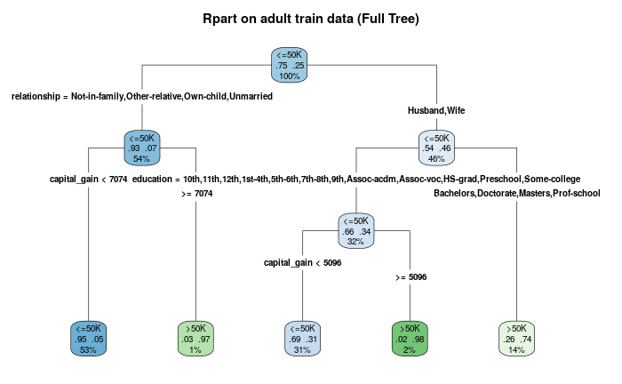

```r
rpart.plot(model, extra=104, fallen.leaves = T, type=4, main="Rpart on adult train data (Full Tree)")
```

### (ii) The first split is done on relationship. The default predicted class is “<=50K” due to class inbalance. The distribution of observations between the “<=50K” and “>50K” classes at first node are 75% and 25% respectively (with 22653 and 7508 observations).

## (c) Use the trained model from (b) to predict the test dataset.

```r
pred <- predict(model, adultTest.df, type="class")
confusionMatrix(pred, as.factor(adultTest.df$income))
```

```
Confusion Matrix and Statistics

          Reference
Prediction <=50K  >50K
     <=50K 10772  1837
     >50K    588  1863

               Accuracy : 0.839
                 95% CI : (0.833, 0.845)
    No Information Rate : 0.754
    P-Value [Acc > NIR] : <2e-16

                  Kappa : 0.51

 Mcnemar's Test P-Value : <2e-16

            Sensitivity : 0.948
            Specificity : 0.504
         Pos Pred Value : 0.854
         Neg Pred Value : 0.760
             Prevalence : 0.754
         Detection Rate : 0.715
   Detection Prevalence : 0.837
      Balanced Accuracy : 0.726

       'Positive' Class : <=50K
```

### (i) The balanced accuracy of the model is 72.6%

### (ii) The balanced error rate of the model is 27.4%

### (iii) The sensitivity and specificity are 94.8% and 50.4% respectively.

### (iv) The AUC of the ROC curve is 84.3%.

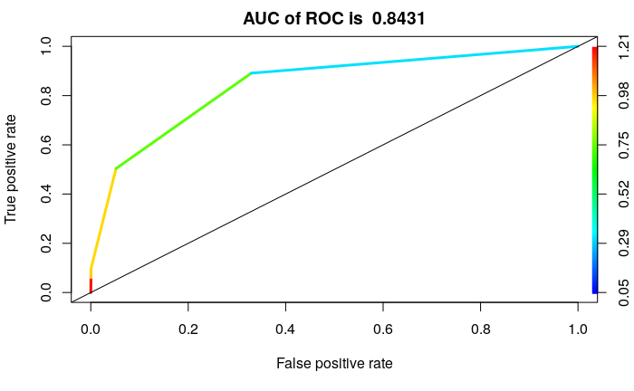

```r
pred.rocr <- predict(model, newdata=adultTest.df, type="prob")[,2]
f.pred <- prediction(pred.rocr, adultTest.df$income)
f.perf <- performance(f.pred, "tpr", "fpr")
auc <- performance(f.pred, measure = "auc")
plot(f.perf, colorize=T, lwd=3,main=paste("AUC of ROC is ", round(auc@y.values[[1]], 4)))
abline(0,1)
```

## (d)In this case, this tree would not benefit from pruning since at each split level the error decreases, including the cross validation error. Therefore, pruning this tree will increase the overall error of the model.

```r
options("digits"=5)
printcp(model)
```

```
Classification tree:
rpart(formula = income ~ ., data = adultTrain.df, method = "class")

Variables actually used in tree construction:
[1] capital_gain education    relationship

Root node error: 7508/30161 = 0.249

n= 30161

      CP nsplit rel error xerror    xstd
1 0.1300      0     1.000  1.000 0.01000
2 0.0642      2     0.740  0.740 0.00897
3 0.0373      3     0.676  0.676 0.00865
4 0.0100      4     0.639  0.639 0.00846
```

## e) Working with class imbalance problem in the training dataset.

### (i)There are 22653 observations in the class “<=50K” and 7508 observations with the class “>50K”

```r
table (adultTrain.df$income)
```

```
<=50K  >50K
22653  7508
```

### (ii) Creating a balanced training dataset by undersampling.

```r
newTrainingDataset <- adultTrain.df[-sample(which(adultTrain.df$income =="<=50K"),22653-7508),]
table(newTrainingDataset$income)
```

```
<=50K  >50K
 7508  7508
```

### (iii) Training a new model based on the new balanced training dataset.

```r
balanceModel <- rpart(income ~ ., method="class", data=newTrainingDataset)
```

```r
balPred <- predict(balanceModel, adultTest.df, type="class")
confusionMatrix(balPred, as.factor(adultTest.df$income))
```

```
Confusion Matrix and Statistics

          Reference
Prediction <=50K >50K
     <=50K  8826  633
     >50K   2534 3067

               Accuracy : 0.79
                 95% CI : (0.783, 0.796)
    No Information Rate : 0.754
    P-Value [Acc > NIR] : <2e-16

                  Kappa : 0.516

 Mcnemar's Test P-Value : <2e-16

            Sensitivity : 0.777
            Specificity : 0.829
         Pos Pred Value : 0.933
         Neg Pred Value : 0.548
             Prevalence : 0.754
         Detection Rate : 0.586
   Detection Prevalence : 0.628
      Balanced Accuracy : 0.803

       'Positive' Class : <=50K
```

### (iv) The AUC of the ROC curve is 84.5%.

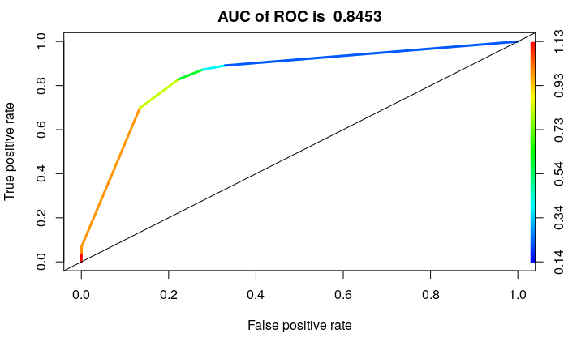

```r
balpred.rocr <- predict(balanceModel, newdata=adultTest.df, type="prob")[,2]
f.balpred <- prediction(balpred.rocr, adultTest.df$income)
f.balperf <- performance(f.balpred, "tpr", "fpr")
balauc <- performance(f.balpred, measure = "auc")
plot(f.balperf, colorize=T, lwd=3,main=paste("AUC of ROC is ", round(balauc@y.values[[1]], 4)))
abline(0,1)
```

#2.2 Random Forest ## (a) Create a RF model using the entire training dataset.

```r
set.seed(1122)
model <- randomForest(income ~ ., data=adultTrain.df,importance=T)
```

```r
pred <- predict(model, adultTest.df, type="class")
confusionMatrix(pred, as.factor(adultTest.df$income))
```

```
Confusion Matrix and Statistics

          Reference
Prediction <=50K  >50K
     <=50K 10563  1340
     >50K    797  2360

               Accuracy : 0.858
                 95% CI : (0.852, 0.864)
    No Information Rate : 0.754
    P-Value [Acc > NIR] : <2e-16

                  Kappa : 0.597

 Mcnemar's Test P-Value : <2e-16

            Sensitivity : 0.930
            Specificity : 0.638
         Pos Pred Value : 0.887
         Neg Pred Value : 0.748
             Prevalence : 0.754
         Detection Rate : 0.701
   Detection Prevalence : 0.790
      Balanced Accuracy : 0.784

       'Positive' Class : <=50K
```

### (i) The balanced accuracy of the model is 78.4%

### (ii) The accuracy of the model is 85.8%

### (iii) The sensitivity and specificity are 93.0% and 63.8% respectively.

### (iv) There are 75.4% observations (11360) labeled “<=50K” and 24.6% observations (3700) labeled with class “>50K”

```r
table(adultTest.df$income)
```

```
<=50K  >50K
11360  3700
```

### (v) They make sense because there is a reduction in the error by the ussage of several trees but there still are more “<=50K” observations in the training data so they will be more likely to be flag as a false positive. However, the specificity was still far better (13.4%) better than the unbalance desicion tree without random forest.

### (vi) For MeanDecreaseAccuracy, the most important variable is capital_gain and the least important one is fnlwgt. For MeanDecreaseGini, the most important variable is relationship and the least important one is race.

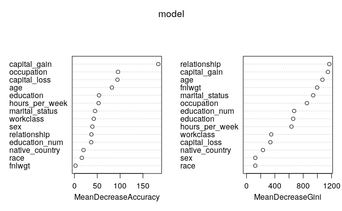

```r
varImpPlot(model)
```

### (vii) the number of variables tried at each split is 3.

```r
print(model)
```

```
Call:
 randomForest(formula = income ~ ., data = adultTrain.df, importance = T)
               Type of random forest: classification
                     Number of trees: 500
No. of variables tried at each split: 3

        OOB estimate of  error rate: 13.78%
Confusion matrix:
      <=50K >50K class.error
<=50K 21096 1557    0.068733
>50K   2599 4909    0.346164
```

## (b) Tuning RF model by finding the best mtry value.

```
mtry = 3  OOB error = 13.86%
Searching left ...
mtry = 2    OOB error = 13.71%
0.011005 0.01
Searching right ...
mtry = 4    OOB error = 14.14%
-0.03193 0.01
```

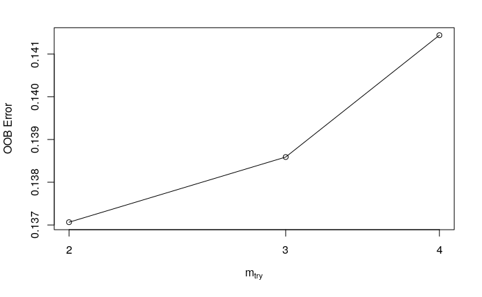

```r
mtry <- tuneRF(adultTrain.df[,-ncol(adultTrain.df)], adultTrain.df$income, ntreeTry=500, stepFactor=1.5,improve=0.01, trace=TRUE, plot=TRUE)
```

```r
print(mtry)
```

```
      mtry OOBError
2.OOB    2  0.13706
3.OOB    3  0.13859
4.OOB    4  0.14144
```

### (ii) The optimal split value is 2.

### (iii) creating and testing new model with mtry=2

```r
optmodel <- randomForest(income ~ ., data=adultTrain.df,importance=T,mtry=2)
optpred <-predict(optmodel, adultTest.df, type="class")
confusionMatrix(optpred, as.factor(adultTest.df$income))
```

```
Confusion Matrix and Statistics

          Reference
Prediction <=50K  >50K
     <=50K 10617  1358
     >50K    743  2342

               Accuracy : 0.86
                 95% CI : (0.855, 0.866)
    No Information Rate : 0.754
    P-Value [Acc > NIR] : <2e-16

                  Kappa : 0.601

 Mcnemar's Test P-Value : <2e-16

            Sensitivity : 0.935
            Specificity : 0.633
         Pos Pred Value : 0.887
         Neg Pred Value : 0.759
             Prevalence : 0.754
         Detection Rate : 0.705
   Detection Prevalence : 0.795
      Balanced Accuracy : 0.784

       'Positive' Class : <=50K
```

#### (1) The balanced accuracy of the model is 78.4%

#### (2) The accuracy of the model 86.0%

#### (3) The sensitivity and specificity of the model are 93.5% and 63.3% respectively.

#### (4) For MeanDecreaseAccuracy, the most important variable is capital_gain and least important is fnlwgt. For MeanDecreaseGini, the most important variableis capital_gain and the least important one is race.

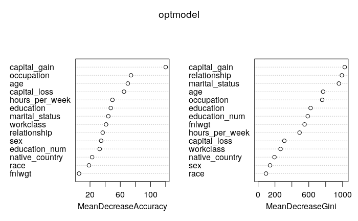

```r
varImpPlot(optmodel)
```

# 2.3 Association rules

```r
set.seed(1122)
library(arules)
library(arulesViz)
setwd(".")
rm(list=ls())
```

```r
trans <- read.transactions("groceries.csv", sep=",")
summary(trans)
```

```
transactions as itemMatrix in sparse format with
 9835 rows (elements/itemsets/transactions) and
 169 columns (items) and a density of 0.026091

most frequent items:
      whole milk other vegetables       rolls/buns             soda           yogurt          (Other)
            2513             1903             1809             1715             1372            34055

element (itemset/transaction) length distribution:
sizes
   1    2    3    4    5    6    7    8    9   10   11   12   13   14   15   16   17   18   19   20   21
2159 1643 1299 1005  855  645  545  438  350  246  182  117   78   77   55   46   29   14   14    9   11
  22   23   24   26   27   28   29   32
   4    6    1    1    1    1    3    1

   Min. 1st Qu.  Median    Mean 3rd Qu.    Max.
   1.00    2.00    3.00    4.41    6.00   32.00

includes extended item information - examples:
```

|  | labels |
| --- | --- |
| 1 | abrasive cleaner |
| 2 | artif. sweetener |
| 3 | baby cosmetics |

## (i) Running apriori() on the transaction set with a support value of 0.1. Using the default, we generate zero rules.

```r
f_is <-apriori(trans, parameter = list(support=0.1))
```

```
Apriori

Parameter specification:
```

|  | confidence | minval | smax | arem | aval | originalSupport | maxtime | support | minlen | maxlen | target | ext |
| --- | --- | --- | --- | --- | --- | --- | --- | --- | --- | --- | --- | --- |
|  | 0.8 | 0.1 | 1 | none | FALSE | TRUE | 5 | 0.1 | 1 | 10 | rules | FALSE |

```
Algorithmic control:
```

|  | filter | tree | heap | memopt | load | sort | verbose |
| --- | --- | --- | --- | --- | --- | --- | --- |
|  | 0.1 | TRUE | TRUE | FALSE | TRUE | 2 | TRUE |

```
Absolute minimum support count: 983

set item appearances ...[0 item(s)] done [0.00s].
set transactions ...[169 item(s), 9835 transaction(s)] done [0.01s].
sorting and recoding items ... [8 item(s)] done [0.00s].
creating transaction tree ... done [0.01s].
checking subsets of size 1 2 done [0.00s].
writing ... [0 rule(s)] done [0.00s].
creating S4 object  ... done [0.01s].
```

```r
summary(f_is)
```

```
set of 0 rules
```

```r
rm(f_is)
```

## (ii) We get 400 rules by having a support value of 0.001 in order to get at least 400 rules (410 rules).

```r
f_is <-apriori(trans, parameter = list(support=0.001))
```

```
Apriori

Parameter specification:
```

|  | confidence | minval | smax | arem | aval | originalSupport | maxtime | support | minlen | maxlen | target | ext |
| --- | --- | --- | --- | --- | --- | --- | --- | --- | --- | --- | --- | --- |
|  | 0.8 | 0.1 | 1 | none | FALSE | TRUE | 5 | 0.001 | 1 | 10 | rules | FALSE |

```
Algorithmic control:
```

|  | filter | tree | heap | memopt | load | sort | verbose |
| --- | --- | --- | --- | --- | --- | --- | --- |
|  | 0.1 | TRUE | TRUE | FALSE | TRUE | 2 | TRUE |

```
Absolute minimum support count: 9

set item appearances ...[0 item(s)] done [0.00s].
set transactions ...[169 item(s), 9835 transaction(s)] done [0.01s].
sorting and recoding items ... [157 item(s)] done [0.00s].
creating transaction tree ... done [0.01s].
checking subsets of size 1 2 3 4 5 6 done [0.04s].
writing ... [410 rule(s)] done [0.00s].
creating S4 object  ... done [0.02s].
```

```r
summary(f_is)
```

```
set of 410 rules

rule length distribution (lhs + rhs):sizes
  3   4   5   6
 29 229 140  12

   Min. 1st Qu.  Median    Mean 3rd Qu.    Max.
   3.00    4.00    4.00    4.33    5.00    6.00

summary of quality measures:
    support          confidence         lift           count
 Min.   :0.00102   Min.   :0.800   Min.   : 3.13   Min.   :10.0
 1st Qu.:0.00102   1st Qu.:0.833   1st Qu.: 3.31   1st Qu.:10.0
 Median :0.00122   Median :0.846   Median : 3.59   Median :12.0
 Mean   :0.00125   Mean   :0.866   Mean   : 3.95   Mean   :12.3
 3rd Qu.:0.00132   3rd Qu.:0.909   3rd Qu.: 4.34   3rd Qu.:13.0
 Max.   :0.00315   Max.   :1.000   Max.   :11.24   Max.   :31.0

mining info:
```

|  | data | ntransactions | support | confidence |
| --- | --- | --- | --- | --- |
|  | trans | 9835 | 0.001 | 0.8 |

## (iii) According to summary the most frequent element is whole milk bought 2513 times followed by other vegetables bought 1903 times

```r
summary(trans)
```

```
transactions as itemMatrix in sparse format with
 9835 rows (elements/itemsets/transactions) and
 169 columns (items) and a density of 0.026091

most frequent items:
      whole milk other vegetables       rolls/buns             soda           yogurt          (Other)
            2513             1903             1809             1715             1372            34055

element (itemset/transaction) length distribution:
sizes
   1    2    3    4    5    6    7    8    9   10   11   12   13   14   15   16   17   18   19   20   21
2159 1643 1299 1005  855  645  545  438  350  246  182  117   78   77   55   46   29   14   14    9   11
  22   23   24   26   27   28   29   32
   4    6    1    1    1    1    3    1

   Min. 1st Qu.  Median    Mean 3rd Qu.    Max.
   1.00    2.00    3.00    4.41    6.00   32.00

includes extended item information - examples:
```

|  | labels |
| --- | --- |
| 1 | abrasive cleaner |
| 2 | artif. sweetener |
| 3 | baby cosmetics |

## (iv) The least frequent element is baby food with only one item sold.

```r
sort(table(unlist(LIST(trans))))[1:1]
```

```
baby food
        1
```

## (v) The top 5 rules sorted by suport are:

```r
inspect(sort(f_is, by='support', decreasing = T)[1:5])
```

```
    lhs                   rhs                  support confidence   lift count
[1] {citrus fruit,
     root vegetables,
     tropical fruit,
     whole milk}       => {other vegetables} 0.0031520    0.88571 4.5775    31
[2] {curd,
     domestic eggs,
     other vegetables} => {whole milk}       0.0028470    0.82353 3.2230    28
[3] {curd,
     hamburger meat}   => {whole milk}       0.0025419    0.80645 3.1562    25
[4] {herbs,
     rolls/buns}       => {whole milk}       0.0024403    0.80000 3.1309    24
[5] {herbs,
     tropical fruit}   => {whole milk}       0.0023386    0.82143 3.2148    23
```

## (vi) The top 5 rules, sorted by confidence are:

```r
inspect(sort(f_is, by='confidence', decreasing = T)[1:5])
```

|  | lhs |  | rhs | support | confidence | lift | count |
| --- | --- | --- | --- | --- | --- | --- | --- |
| [1] | {rice,sugar} | => | {whole milk} | 0.0012201 | 1 | 3.9136 | 12 |
| [2] | {canned fish,hygiene articles} | => | {whole milk} | 0.0011185 | 1 | 3.9136 | 11 |
| [3] | {butter,rice,root vegetables} | => | {whole milk} | 0.0010168 | 1 | 3.9136 | 10 |
| [4] | {flour,root vegetables,whipped/sour cream} | => | {whole milk} | 0.0017285 | 1 | 3.9136 | 17 |
| [5] | {butter,domestic eggs,soft cheese} | => | {whole milk} | 0.0010168 | 1 | 3.9136 | 10 |

## (vii) The bottom 5 rules, sorted by support are:

```r
inspect(sort(f_is, by='support', decreasing = F)[1:5])
```

|  | lhs |  | rhs | support | confidence | lift | count |
| --- | --- | --- | --- | --- | --- | --- | --- |
| [1] | {cereals,curd} | => | {whole milk} | 0.0010168 | 0.90909 | 3.5579 | 10 |
| [2] | {butter,jam} | => | {whole milk} | 0.0010168 | 0.83333 | 3.2614 | 10 |
| [3] | {pastry,sweet spreads} | => | {whole milk} | 0.0010168 | 0.90909 | 3.5579 | 10 |
| [4] | {butter,rice,root vegetables} | => | {whole milk} | 0.0010168 | 1.00000 | 3.9136 | 10 |
| [5] | {other vegetables,rice,tropical fruit} | => | {whole milk} | 0.0010168 | 0.83333 | 3.2614 | 10 |

## (viii)The bottom 5 rules, sorted by confidence are:

```r
inspect(sort(f_is, by='confidence', decreasing = F)[1:5])
```

|  | lhs |  | rhs | support | confidence | lift | count |
| --- | --- | --- | --- | --- | --- | --- | --- |
| [1] | {curd,turkey} | => | {other vegetables} | 0.0012201 | 0.8 | 4.1345 | 12 |
| [2] | {fruit/vegetable juice,herbs} | => | {other vegetables} | 0.0012201 | 0.8 | 4.1345 | 12 |
| [3] | {herbs,rolls/buns} | => | {whole milk} | 0.0024403 | 0.8 | 3.1309 | 24 |
| [4] | {onions,waffles} | => | {other vegetables} | 0.0012201 | 0.8 | 4.1345 | 12 |
| [5] | {root vegetables,tropical fruit,turkey} | => | {other vegetables} | 0.0012201 | 0.8 | 4.1345 | 12 |